# Исследование объявлений о продаже квартир

## Влияние дня размещения на цену квартиры

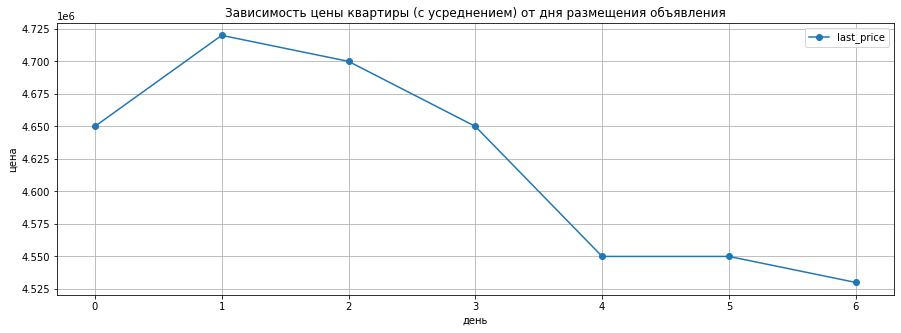

```python
#V5
df.pivot_table(index='weekday_exposition', values='last_price', aggfunc='median').reset_index().plot(
                      x='weekday_exposition', y='last_price', grid=True, figsize = (15, 5), style='o-').set(
                      title='Зависимость цены квартиры (с усреднением) от дня размещения объявления',
                      xlabel='день', ylabel='цена');
```

- Разница между наибольшей и наименьшей ценой находится на уровне чуть менее 4%, что в пределах статпогрешности и как значимый параметр может не рассматриваться при заключении сделки.

### Исследование средней цены одного квадратного метра в 10 населённых пунктах с наибольшим числом объявлений

```python
#Выборка 10 населённых пунктов с наибольшим числом объявлений
top_10 = df['locality_name'].value_counts().head(10)
top_10 = top_10.reset_index().rename(columns = {'locality_name':'lots','index':'locality_name'})
top_10
```

|  | locality_name | lots |
| --- | --- | --- |
| 0 | Санкт-Петербург | 15650 |
| 1 | Мурино | 586 |
| 2 | Кудрово | 470 |
| 3 | Шушары | 439 |
| 4 | Всеволожск | 398 |
| 5 | Пушкин | 369 |
| 6 | Колпино | 338 |
| 7 | Парголово | 327 |
| 8 | Гатчина | 307 |
| 9 | Выборг | 237 |

```python
#расчёт средней стоимости кв м для топ-10, список для сохранения значений средней стоимости 1 кв.м.
top_msq = []

#средние значения цены 1 кв.м. в топ-10 и добавления
#значений в список top_sqm :
for name in top_10['locality_name']:
    top_msq.append(round(df.query('locality_name == @name')['per_sq_meter'].mean()))

top_10['lots'] = top_msq
top_10 = top_10.sort_values('lots', ascending=False)
display(top_10)
```

|  | locality_name | lots |
| --- | --- | --- |
| 0 | Санкт-Петербург | 114876 |
| 5 | Пушкин | 103126 |
| 2 | Кудрово | 95261 |
| 7 | Парголово | 90176 |
| 1 | Мурино | 86041 |
| 3 | Шушары | 78551 |
| 6 | Колпино | 75425 |
| 8 | Гатчина | 68746 |
| 4 | Всеволожск | 68654 |
| 9 | Выборг | 58142 |

```python
#поиск городов с самой низкой и самой высокой ценой
top_10.query('lots == lots.min() or lots == lots.max()')
```

|  | locality_name | lots |
| --- | --- | --- |
| 0 | Санкт-Петербург | 114876 |
| 9 | Выборг | 58142 |

Наибольшая средняя - в Петербурге, наименьшая - в Выборге, ничего удивительного.

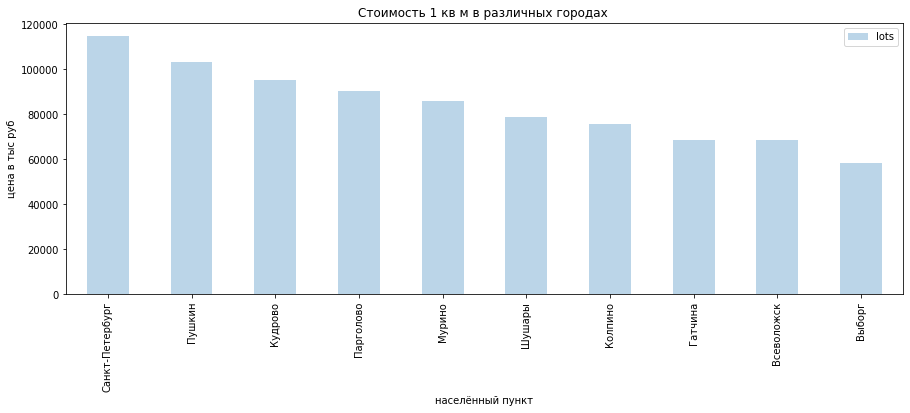

```python
#плотбар по НП
top_10.plot(x='locality_name', y='lots', kind='bar', alpha=0.3, figsize=(15, 5),
                       title='Стоимость 1 кв м в различных городах ').set(
                       xlabel='населённый пункт', ylabel='цена в тыс руб');
#plt.xlim(0, 200)
#plt.ylim(0, 60000000)
plt.show()
```

### Исследование средней стоимости квартиры в зависимости от удаления от центра СПБ

```python
#V5
# отбор объявлений по локации
SPB = df.query('locality_name == "Санкт-Петербург"')
```

```python
#V5
#создание таблицы из 2х стоблцов для сопоставления удалённости от центра и цены за кв м
table = SPB.pivot_table(index=('city_centers_nearest_km'), values='last_price', aggfunc='mean').reset_index()
```

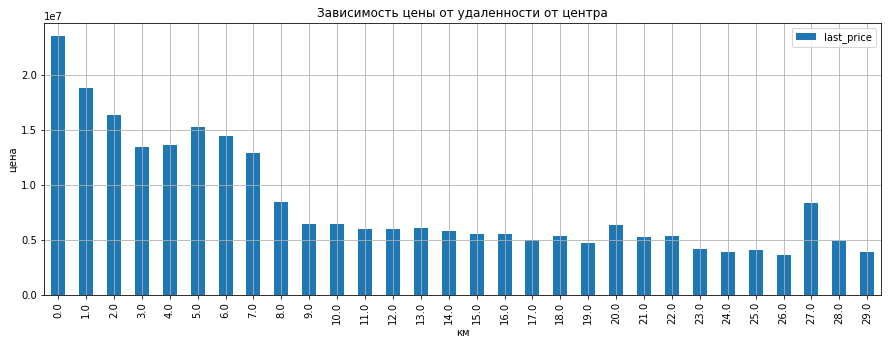

```python
#V5
#построение столбчатой диаграммы по значениям SPB:
table.plot(x='city_centers_nearest_km', y='last_price', kind='bar', grid=True, figsize=(15, 5),
         title='Зависимость цены от удаленности от центра').set(xlabel='км', ylabel='цена');

#top_10.plot(x='locality_name', y='lots', kind='bar', alpha=0.3, figsize=(15, 5),
                       #title='Стоимость 1 кв м в различных городах ').set(
                       #xlabel='населённый пункт', ylabel='цена в тыс руб');
#plt.xlim(0, 200)
#plt.ylim(0, 60000000)
plt.show()
```

Исходя из графика, построенного по средним ценам квартир, чья принадлежность явно указана как "город Санкт-Петербург", корелляция между ценой и расстоянием от центра отрицательная, сильная до 9км, слабая - от 9 до 20 км, где проходит условная линия КАД, выброс на 27 км - скорей всего, влияние высокой цены одного или нескольких объектов. Условно говоря, в радиусе от 9 до 22 км от центра квартиры находятся в одном ценовом диапазоне и выбор жилья должен проводиться по другим, уже более определяющим критериям.